# Covid-19 Food Systems Database Analysis

Robert Berry

20 January, 2022

All of the tables and plots shown on this website can be accessed as individual files [HERE](https://connectglosac-my.sharepoint.com/:f:/g/personal/s2111547_glos_ac_uk/Et1CEJKr6lNDixyBZv6ApQcB32CNUmTerHOikgHynM9_-Q?e=pjRdLX)

## 1. Data import and cleaning

Load data and prepare for analysis:

```
#> 1.1 Load libraries
```

```r
library(tidyverse) # Data muncging and analysis
library(here) # relative path management for reproducibility
library(lubridate) # for date string manipulation/conversion
library(janitor) # data cleaning functions
library(knitr) # report rendering with rmarkdown
library(ggplot2) # plots and visualisations
db <- read_csv(here("In", "C19_Food_DB_220114.csv"), trim_ws = TRUE)
```

Table 1.1 Original database (“db”) on import - **1526** records

```
## Rows: 1,526
## Columns: 9
## $ Title                <chr> "City Region Food Systems Building Resilience to ~
## $ `Author(s) / Source` <chr> "Urbanet", "YES! Magazine", "Manchester Evening N~
## $ `Article Type`       <chr> "Web page", "Magazine article", "News article", "~
## $ Date                 <chr> "27/11/2021", "12/10/2021", "01/10/2021", "12/11/~
## $ `Theme(s)`           <chr> "Urban Food Systems", "Urban Food Systems", "Reta~
## $ WWW                  <chr> "<a href=\"https://www.urbanet.info/city-region-f~
## $ `Sub-Theme(s)`       <chr> "Urban Food Systems – General", "Urban Food Syste~
## $ Summary              <chr> "the pandemic has again shown that urban food sys~
## $ Keywords             <chr> "urban food systems, resilience", "urban food, fo~
```

```
#> 1.3 Prep for analysis (clean, tidy, transform)
#> Rename columns
```

```r
db <- db |>
  rename(AUTH_SOURCE = `Author(s) / Source`, TYPE = `Article Type`, THEME_MAIN=`Theme(s)`, THEME_SUB = `Sub-Theme(s)`)
for( i in colnames(db)){
    colnames(db)[which(colnames(db)==i)] = toupper(i)
}
```

```
#> Remove i
```

```r
rm(i)
```

```
#> Convert date format to YYYY/MM/DD for analysis and sorting by date
```

```r
db$DATE <- as.Date(lubridate::parse_date_time(db$DATE, c('dmy', 'ymd')))
```

```
#> Remove empty records where all columns are "NA"
```

```r
# Following filters rows with at least one column not "NA"
db <- janitor::remove_empty(db, which = "rows")
```

```
#> Remove duplicates
```

```r
db <- db |> distinct()

# Add unique ID column
# First sort by date (oldest first)
db <- db |>
  arrange(DATE)
# Add ID col
db$UID <- seq.int(nrow(db))
# Bring new UID column to front
db <- db |> select(UID, everything())
```

```
#> replace ampersand string "&amp;" with "&" in selected columns
```

```r
db$THEME_MAIN <- (gsub("&amp;", "&", db$THEME_MAIN))
db$THEME_SUB <- (gsub("&amp;", "&", db$THEME_SUB))
```

```
#> Export as CSV
```

```r
write_csv(db, here("Out", "Descriptive_Stats", "1_Current_Database_Cleaned", paste0("C19_Food_DB_Cleaned_", Sys.Date(), ".csv")))
```

Table 1.2 Processed database after cleaning and pre-processing**1524** records

```
## Rows: 1,524
## Columns: 10
## $ UID         <int> 1, 2, 3, 4, 5, 6, 7, 8, 9, 10, 11, 12, 13, 14, 15, 16, 17,~
## $ TITLE       <chr> "Cities and local governments at the forefront in building~
## $ AUTH_SOURCE <chr> "FAO", "Joy Carey", NA, "Mary Quicke", "Jonty Bloom", "The~
## $ TYPE        <chr> "Report", "Report", "Web page", "Blog post", "News article~
## $ DATE        <date> 2019-07-28, 2020-03-14, 2020-03-14, 2020-03-14, 2020-03-2~
## $ THEME_MAIN  <chr> "Urban Food Systems", "Urban Food Systems", "Dairy & Chees~
## $ WWW         <chr> "<a href=\"http://www.fao.org/documents/card/en/c/cb0407en~
## $ THEME_SUB   <chr> "Urban Food Systems – General", "Urban Food Systems – Gene~
## $ SUMMARY     <chr> "Survey data and case studies from cities around the world~
## $ KEYWORDS    <chr> "global, urban food systems, resilience, food security", "~
```

*(**Note 20/01/21** - requires further processing - e.g. new cols for shortened theme names)*

## 2. Themes: Count

This section includes tables and plots showing the summary counts of main themes and sub-themes in the database.

### 2.1 Main Themes

This section shows the summary counts for main themes.  
**Note:** a small number of database entries have been allocated multiple main themes (see bottom of table). **Damian** - these can be left as is, or split and counted as single themes - let me know.  
**Also** - note that very long theme names affect the format of tables and plots - we need an alternative set of concise theme names for both main and sub-themes to improve presentation (task for DM and SR).

```
#> Group and count main themes
```

```r
t2.1.theme.m.sum <- db |>
  select(THEME_MAIN) |>
  group_by(THEME_MAIN) |>
  summarise(Count = n()) |>
  arrange(desc(Count))
```

```
#> Render table on web page
```

```r
knitr::kable(t2.1.theme.m.sum, col.names = c("Main theme", "Article count"), caption = "Table 2.1.1 Article count by main theme")
```

Table 2.1.1 Article count by main theme

| Main theme | Article count |
| --- | --- |
| Food Access & Security (UK) | 436 |
| Food Access & Security (Global) | 192 |
| Food System Commentaries | 129 |
| Local Food Networks and Agroecology | 117 |
| Agri-food Labour | 104 |
| Academic articles re. Covid-19 modelling, science, post-normality, uncertainty, etc. | 95 |
| Farming and rural economy: general articles, supporting farmers, valuing farmers, etc | 78 |
| Processing & Distribution | 72 |
| Consumer Behaviour / Consumption | 63 |
| Urban Food Systems | 49 |
| Retail - Independent & Local, plus Food Service | 37 |
| Organisational resources and links (UK) | 31 |
| Dairy & Cheese | 26 |
| Food Waste | 25 |
| Market Data | 17 |
| Retail – Supermarkets | 16 |
| Fisheries | 15 |
| CCRI blogs | 11 |
| CCRI Webinar Footage | 4 |
| Local Food Networks and Agroecology,Consumer Behaviour / Consumption | 2 |
| Agri-food Labour,Processing & Distribution | 1 |
| Agri-food Labour,Retail - Independent & Local, plus Food Service | 1 |
| Consumer Behaviour / Consumption,Food Access & Security (Global) | 1 |
| Dairy & Cheese,Consumer Behaviour / Consumption | 1 |
| Food Access & Security (Global),Food System Commentaries | 1 |

```
#> Export table as CSV file
```

```r
write_csv(t2.1.theme.m.sum, here("Out", "Descriptive_Stats", "2_Themes_Count", "2.1_Main_Themes", "Table2.1_THEMES_MAIN_Count.csv"))
```

```
#> Create (and export) bar plot
```

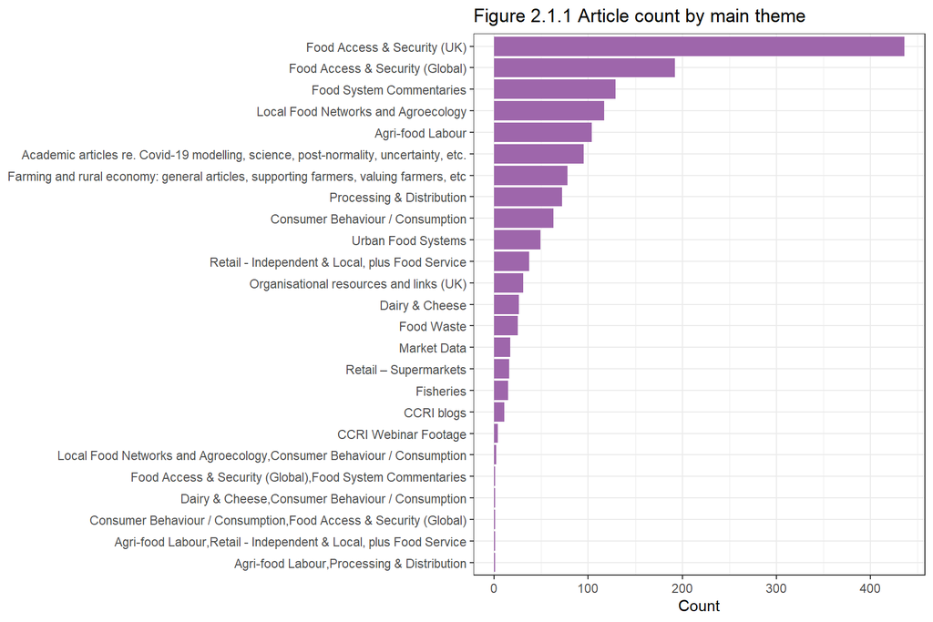

```r
p2.1 <- ggplot(t2.1.theme.m.sum, aes(x = reorder(THEME_MAIN, Count), y = Count)) +
  theme_bw() +
  ggtitle("Figure 2.1.1 Article count by main theme") +
  geom_bar(stat = "identity", fill = "#9e66ab") +
  theme(axis.title.y = element_blank()) +
  coord_flip()
p2.1
```

```r
ggsave(here("Out", "Descriptive_Stats", "2_Themes_Count", "2.1_Main_Themes", "Plot2.1_THEMES_MAIN_Count.png"), width = 9, height = 6)
```

### 2.2 Sub-Themes

This section shows the summary counts for sub-themes.

```
#> Create list of main themes for iteration
```

```r
t2.2_theme.m <- t2.1.theme.m.sum |>
  slice(1:19)
themes <- as.list(t2.2_theme.m$THEME_MAIN)
```

```
#> Sequential integer counter for figure numbers
```

```r
i <-0
```

```
#> Initiate loop
```

```r
for(theme.m in themes){
```

```
#> Loop counter (for table caption number)
```

```r
i <- i+1
```

```
#> Create data table (count of articles by sub-theme per main theme)
```

```r
t2.2_loop <- db |>
 select(THEME_MAIN, THEME_SUB) |>
 filter(THEME_MAIN == theme.m) |>
 group_by(THEME_MAIN, THEME_SUB) |>
 summarise(Count = n()) |>
 ungroup() |>
 select(THEME_SUB, Count) |>
 arrange(desc(Count))
```

```
#> Remove main theme from THEME_SUB string (i.e. all text before and included hyphen)
```

```r
t2.2_loop$THEME_SUB <- gsub("^.*?\\-","", t2.2_loop$THEME_SUB)
```

```
#> Trim WS
```

```r
t2.2_loop$THEME_SUB <- trimws(t2.2_loop$THEME_SUB)

print(knitr::kable(t2.2_loop, col.names = c("Sub-theme", "Article count"), caption = paste0("Table 2.2.", i , ": ", theme.m)))
```

```
#> Add line break
```

```r
cat("\n")
cat("\n")
cat("\n")
```

```
#> Export table as CSV file
```

```r
write_csv(t2.2_loop, here("Out", "Descriptive_Stats", "2_Themes_Count", "2.2_Sub_Themes", paste0("Table 2.2.", i, "_", "_SUB_THEMES_Count.csv")))
```

```
#> Create (and export) bar plot
```

```r
p2.2 <- ggplot(t2.2_loop, aes(x = reorder(THEME_SUB, Count), y = Count)) +
  theme_bw() +
  ggtitle(paste0("Figure 2.2.", i , ": ", theme.m)) +
  geom_bar(stat = "identity", fill =    "#599ad3") +
  theme(axis.title.y = element_blank()) +
  theme(legend.position="none") +
  coord_flip()
```

```
#> Render on web page
```

```r
print(p2.2)
```

```
#> Export plots
```

```r
ggsave(here("Out", "Descriptive_Stats", "2_Themes_Count", "2.2_Sub_Themes", paste0("Figure_2.2.", i, "_", ".png")), width = 9, height = 6)
```

```
#> End loop
```

```r
}
```

Table 2.2.1: Food Access & Security (UK)

| Sub-theme | Article count |
| --- | --- |
| General | 273 |
| Marcus Rashford-led free school meals campaigns and child food insecurity | 85 |
| National Food Strategy | 29 |
| School meals and school and university catering | 13 |
| Reliance on EU food chains, Brexit and food security | 11 |
| EFRA inquiry - food insecurity sessions and COVID-19 and Food Supply Report | 10 |
| Community responses | 7 |
| France’s Covid freight ban | 5 |
| Government announcement to support food charities | 2 |
| General,Local Food Networks and Agroecology – General | 1 |

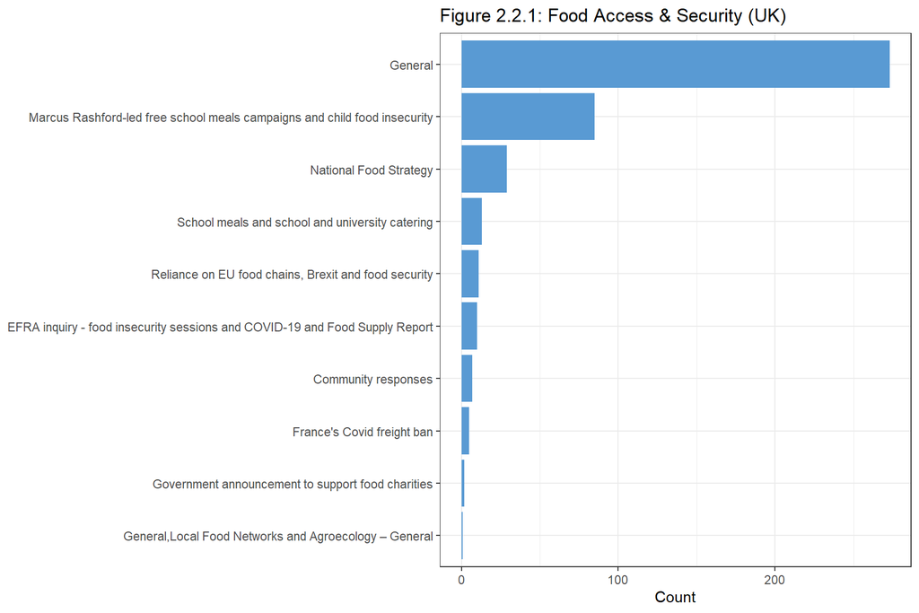

Table 2.2.2: Food Access & Security (Global)

| Sub-theme | Article count |
| --- | --- |
| Other resources and articles (media, academic) | 153 |
| General | 39 |

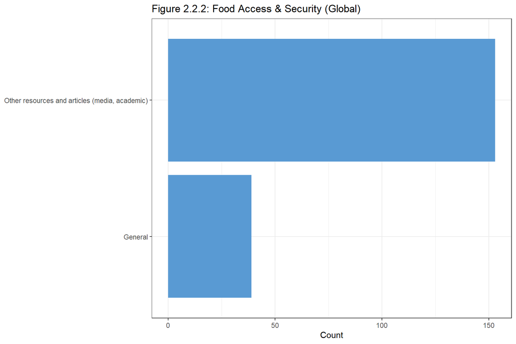

Table 2.2.3: Food System Commentaries

| Sub-theme | Article count |
| --- | --- |
| General | 127 |
| Contexualising Coronavirus Geographically,Food System Commentaries - General | 1 |
| General | 1 |

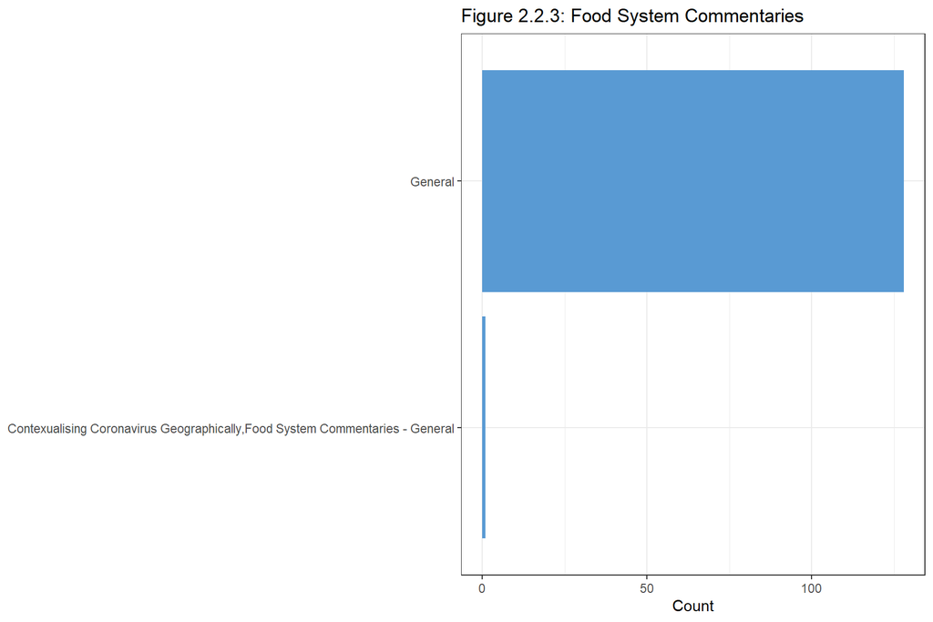

Table 2.2.4: Local Food Networks and Agroecology

| Sub-theme | Article count |
| --- | --- |
| Local Food Networks and Agroecology – General | 71 |
| Local Food Networks and Agroecology – Shortening supply chains (regional resilience) and online platforms | 20 |
| Local Food Networks and Agroecology – Agroecology | 12 |
| Local Food Networks and Agroecology – A more critical relocalisation perspective | 6 |
| line platforms, direct sales directories, buy local listings, etc.) | 6 |
| General | 1 |
| Urban Food Systems – General | 1 |

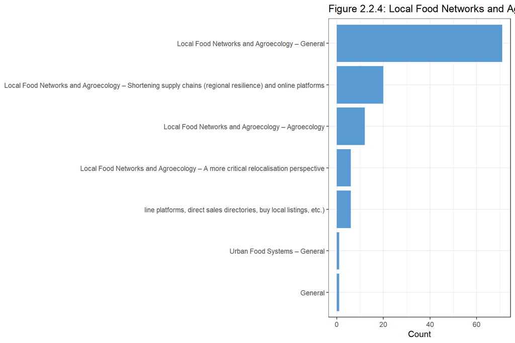

Table 2.2.5: Agri-food Labour

| Sub-theme | Article count |
| --- | --- |
| food Labour - Agri-food labour in the US (esp. meat processing, harvested crops) | 32 |
| food Labour - Labour shortages (New Zealand dairy, veterinary workforce and strawberry farms, Costa Rican coffee, UK poultry (Christmas turkeys)) | 25 |
| food Labour - Workers’ rights | 25 |
| food Labour - The fruit and vegetable harvest, labour shortages and automation | 7 |
| food Labour - Vaccination of key workers in the food chain (UK and US articles) | 6 |
| food Labour - Pick For Britain | 4 |
| Feed The Nation campaign | 2 |
| food Labour - Humanitarian crisis in ag. commodity chains (Fairtrade Foundation) | 1 |
| food Labour - International Labour Migration to Europe’s Rural Regions | 1 |
| food Labour - Workers’ rights,Retail – Supermarkets – General | 1 |

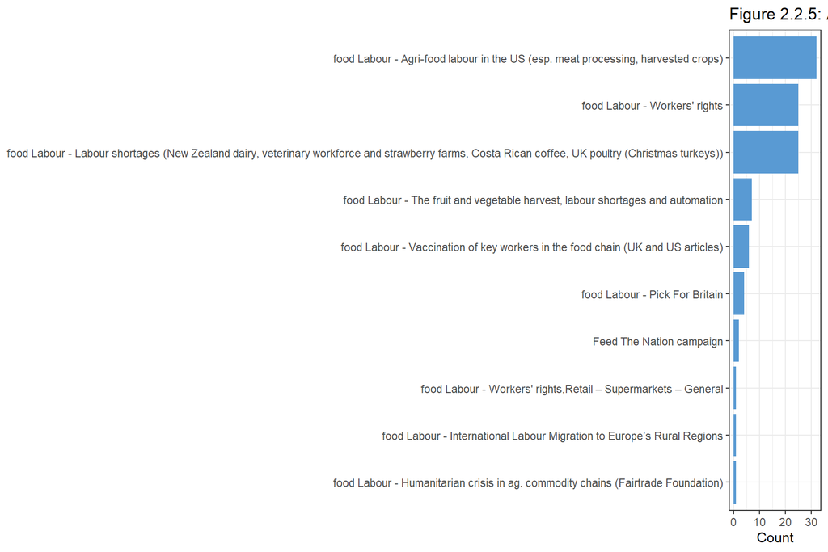

Table 2.2.6: Academic articles re. Covid-19 modelling, science, post-normality, uncertainty, etc.

| Sub-theme | Article count |
| --- | --- |
| Contexualising Coronavirus Geographically | 15 |
| Past (and future?) studies of pandemics, including networked disease | 14 |
| Metaphors | 13 |
| Modelling, social science and animal health links | 11 |
| Uncertainty, pragmatism, the futilities of control and neoliberal economics | 9 |
| Post-normal pandemics | 7 |
| Academic expertise - across disciplines, beyond ‘science’ and interdisciplinarity; plus the gender gaps in COVID-19 decision-making | 4 |
| Viewing the pandemic impact through the lens of the SDGs | 4 |
| Metaphors,Academic articles - Contexualising Coronavirus Geographically | 3 |
| The Covid-19 vaccine and vaccines (selective items) | 3 |
| The psychology of ‘together apart’ | 3 |
| The Slowdown Papers and Times of COVID-19 | 3 |
| Post-normal pandemics,Academic articles - Modelling, social science and animal health links | 2 |
| Disaster resilience | 1 |
| Human infectious disease and global population | 1 |
| Uncertainty, pragmatism, the futilities of control and neoliberal economics | 1 |
| Uncertainty, pragmatism, the futilities of control and neoliberal economics,Academic articles - Metaphors | 1 |

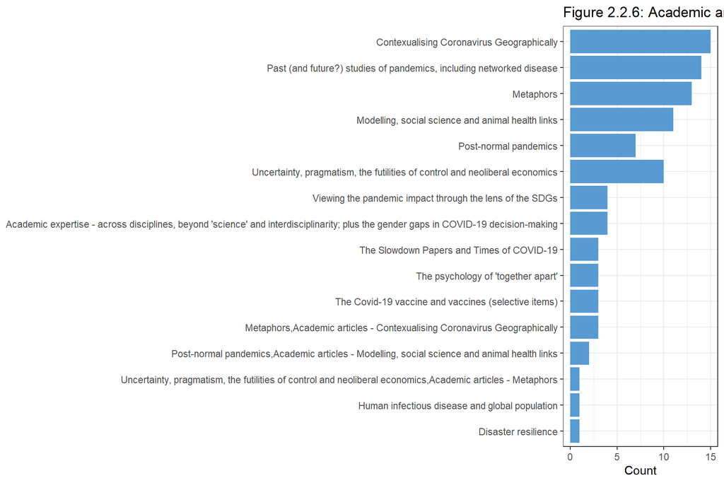

Table 2.2.7: Farming and rural economy: general articles, supporting farmers, valuing farmers, etc

| Sub-theme | Article count |
| --- | --- |
| Valuing and supporting farmers | 19 |
| Digitalisation of agriculture and rural economies | 9 |
| Small-scale farmer incomes / resilience (global) | 7 |
| Valuing and supporting farmers,Consumer Behaviour / Consumption - General | 7 |
| ‘Self-sufficiency day’ (August 21) | 5 |
| Agri-food support packages and 2020 agricultural accounts (Eurostat) | 5 |
| Rural and farmer vulnerability and planning for ‘unexpected events’ | 4 |
| US relief packages | 4 |
| Farm diversification and producer collaboration | 3 |
| Farming Health Hub: COVID-19 Support and Advice | 3 |
| General ,Farming & Rural Economy - Valuing and supporting farmers | 2 |
| #FeedTheNation | 2 |
| Covid-19 and UK-EU trade talks (Brexit) | 2 |
| Valuing and supporting farmers,Farming & Rural Economy - Digitalisation of agriculture and rural economies | 2 |
| Covid-19 is a demand rather than a supply shock? | 1 |
| Covid-19, gender and agriculture | 1 |
| Demand for lifestyle and amenity farms | 1 |
| Farmers as ‘hidden heroes’ | 1 |

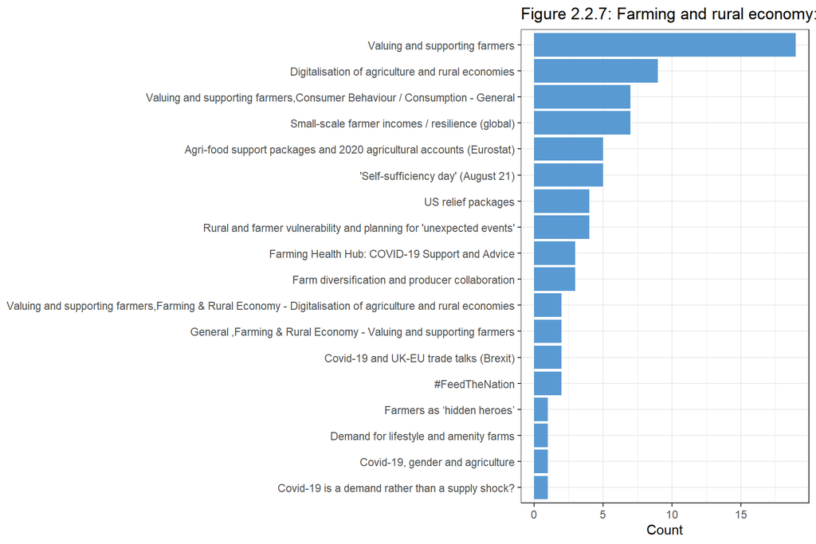

Table 2.2.8: Processing & Distribution

| Sub-theme | Article count |
| --- | --- |
| Meat & food processing plants (US) | 21 |
| Meat & food processing plants (UK) | 16 |
| Meat & food processing plants (Germany, France, the Netherlands) | 8 |
| Supply chain vulnerability and market impacts | 7 |
| Not just meat! | 5 |
| Independent meat processors | 4 |
| Concerns about food fraud | 3 |
| food Labour - Agri-food labour in the US (esp. meat processing, harvested crops),Processing & Distribution - Meat & food processing plants (US) | 2 |
| Independent & Local, plus Food Service - General | 2 |
| Meat & food processing plants (Australia and Brazil) | 2 |
| Food, farming and the rural economy | 1 |
| Meat & food processing plants (US),Agri-food Labour - Agri-food labour in the US (esp. meat processing, harvested crops) | 1 |

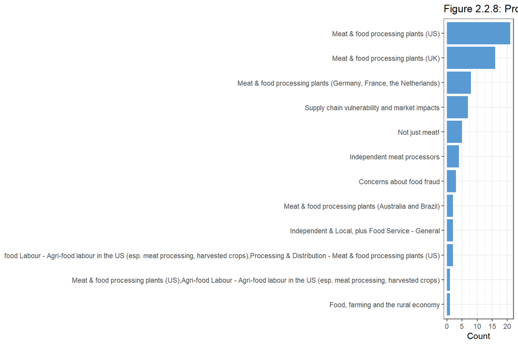

Table 2.2.9: Consumer Behaviour / Consumption

| Sub-theme | Article count |
| --- | --- |
| General | 42 |
| Consumer Behaviour / Consumption – Obesity Strategy | 20 |
| General | 1 |

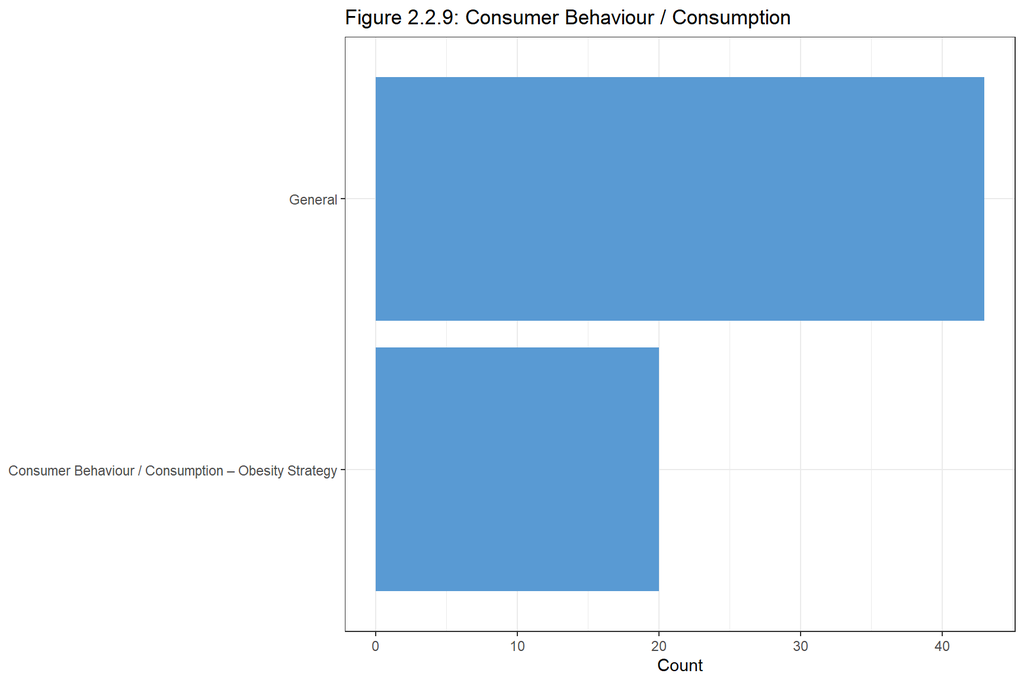

Table 2.2.10: Urban Food Systems

| Sub-theme | Article count |
| --- | --- |
| Urban Food Systems – General | 43 |
| urban relations | 5 |
| General | 1 |

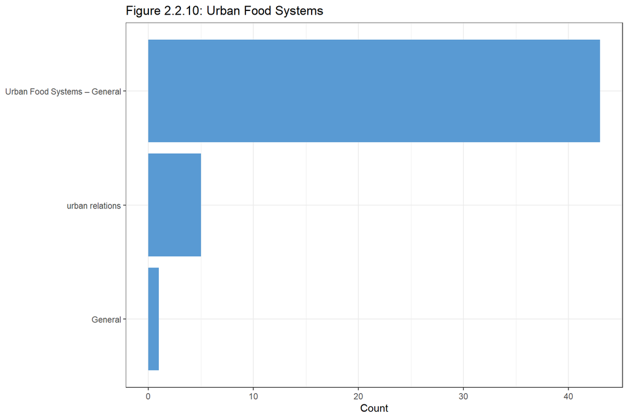

Table 2.2.11: Retail - Independent & Local, plus Food Service

| Sub-theme | Article count |
| --- | --- |
| Independent & Local, plus Food Service - General | 36 |
| Supply chain vulnerability and market impacts | 1 |

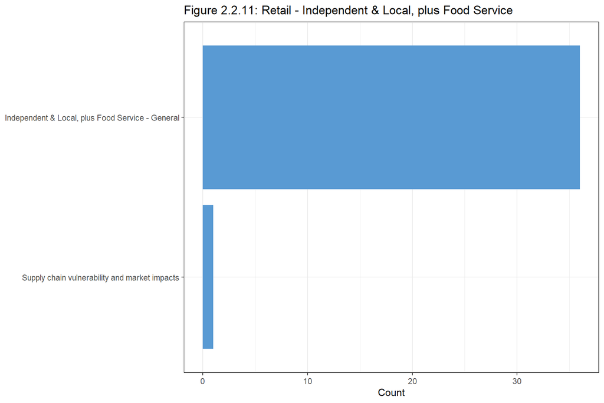

Table 2.2.12: Organisational resources and links (UK)

| Sub-theme | Article count |
| --- | --- |
| Food system organisations | 14 |
| Food, farming and the rural economy | 7 |
| Covid-19 research project tracker and ESRC-funded food system projects | 3 |
| Environment, Food and Rural Affairs (EFRA) Select Committee | 2 |
| National Food Strategy | 2 |
| Food in the time of lockdown | 1 |
| Food, Poverty, Health and the Environment Committee | 1 |
| The Parliamentary Office of Science and Technology (POST) | 1 |

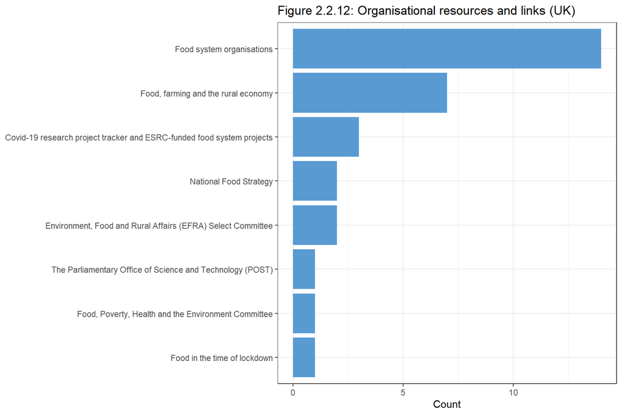

Table 2.2.13: Dairy & Cheese

| Sub-theme | Article count |
| --- | --- |
| Dairy farming crisis and milk waste | 9 |
| Milk Your Moment Campaign and positive dairy sales | 6 |
| Artisan cheese producers | 5 |
| Vending machines, direct selling and networked dairy farm models | 4 |
| Hardship fund for dairy farmers | 2 |

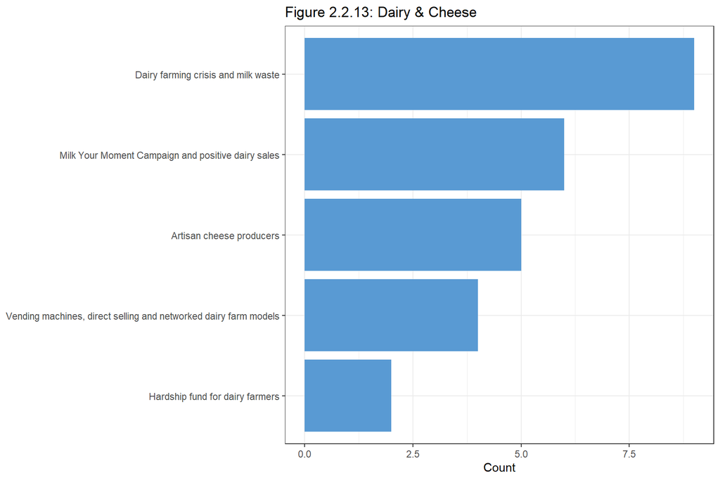

Table 2.2.14: Food Waste

| Sub-theme | Article count |
| --- | --- |
| General | 24 |
| General | 1 |

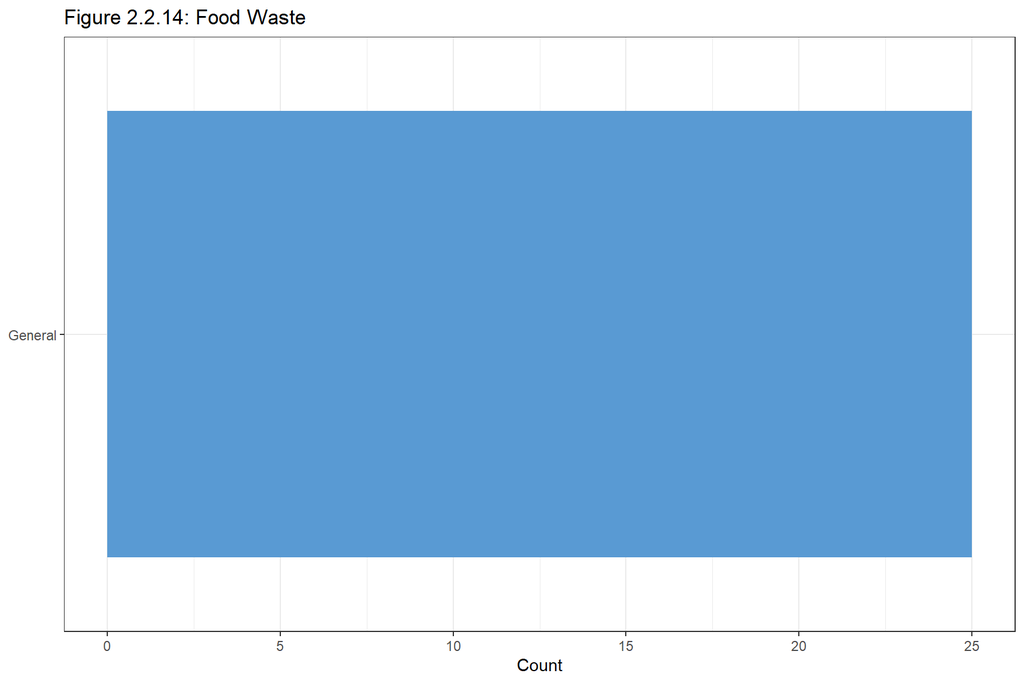

Table 2.2.15: Market Data

| Sub-theme | Article count |
| --- | --- |
| Market Data – International | 12 |
| Market Data – UK | 5 |

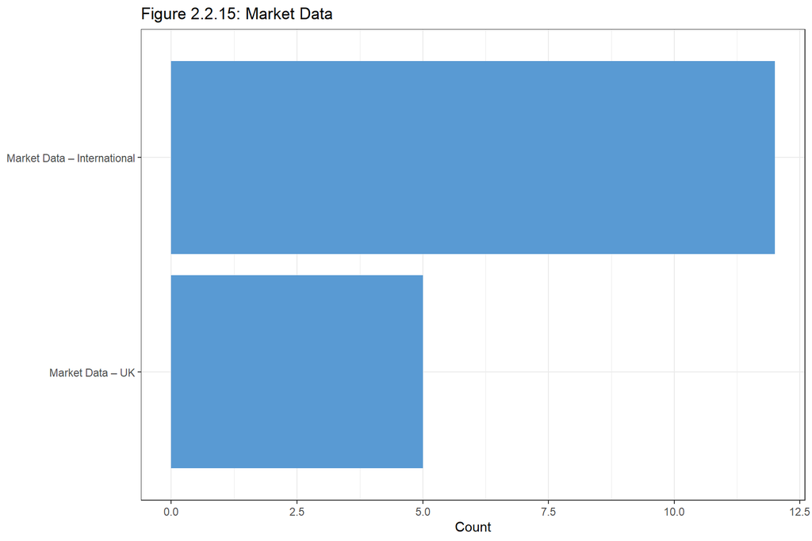

Table 2.2.16: Retail – Supermarkets

| Sub-theme | Article count |
| --- | --- |
| Retail – Supermarkets – General | 10 |
| Retail – Supermarkets – Big food brands moving online | 4 |
| food Labour - Vaccination of key workers in the food chain (UK and US articles) | 1 |
| value horticultural exports (Kenya to European supermarkets) | 1 |

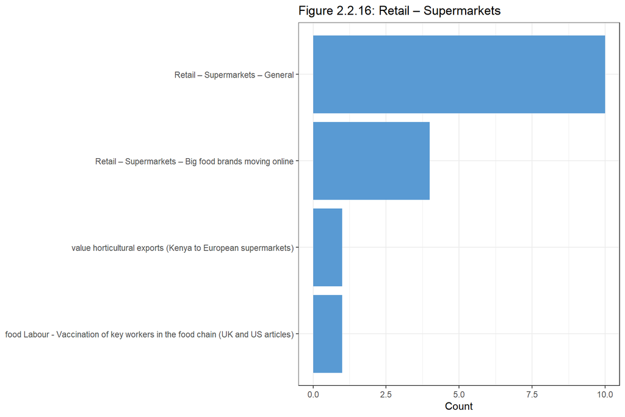

Table 2.2.17: Fisheries

| Sub-theme | Article count |
| --- | --- |
| Fisheries – General | 11 |
| Global supply chains and market systems | 3 |
| General | 1 |

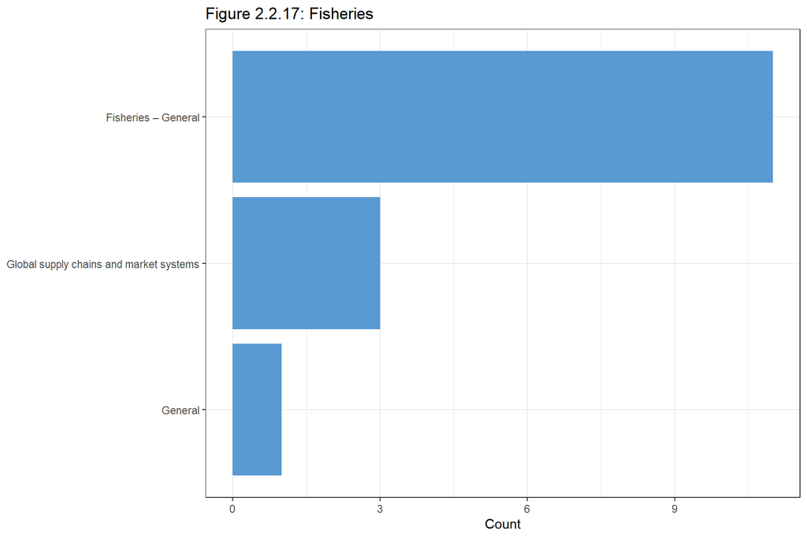

Table 2.2.18: CCRI blogs

| Sub-theme | Article count |
| --- | --- |
| NA | 11 |

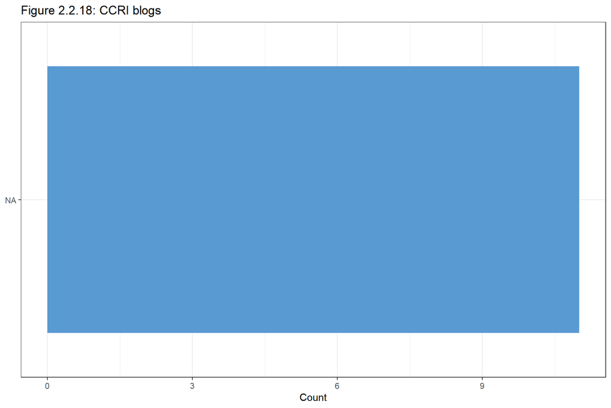

Table 2.2.19: CCRI Webinar Footage

| Sub-theme | Article count |
| --- | --- |
| All | 4 |

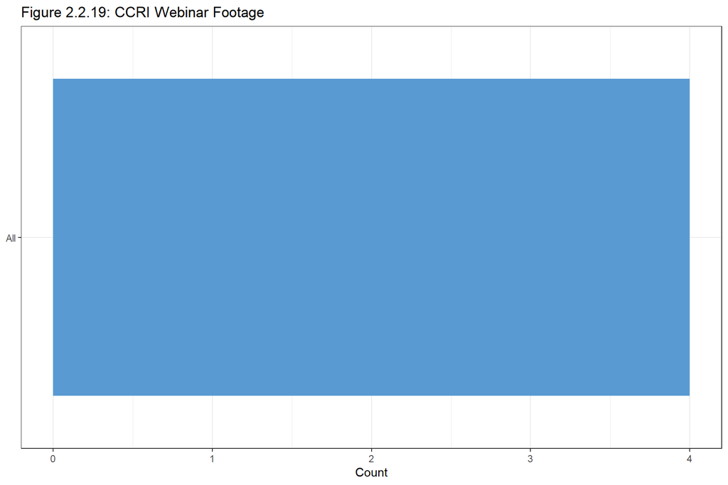

```
#> Remove unwanted variables
```

```r
rm(i)
```

## 3. Themes: Temporal analysis

In this section article occurrences are plotted over time by main theme. The pink rectanges in each plot indicate the time periods of the main Covid lockdowns in England (source: [**HERE**](https://www.instituteforgovernment.org.uk/charts/uk-government-coronavirus-lockdowns))

### 3.1 Main Themes

```
#> Data frame to hold date ranges for lockdows
#> See: https://stackoverflow.com/questions/61479286/how-to-annotate-time-periods-on-line-plots-with-date-axis
```

```r
Lockdowns <- data.frame(date_start= as_date(c("2020-03-23", "2020-11-05", "2021-01-06")),
                        date_end = as_date(c("2020-05-10","2020-12-02", "2021-03-08")))
```

```
#> Sequential integer counter for figure numbers
```

```r
i <-0
```

```
#> Initiate loop
```

```r
for(theme.m in themes){
```

```
#> Loop counter (for table caption number)
```

```r
i <- i+1
```

[output not shown]

```r
#< Tip from: https://stackoverflow.com/questions/47503159/ggplot-using-grouped-date-variables-such-as-year-month
t3.1_theme.m.t <- db |>
  select(UID, THEME_MAIN, DATE) |>
  filter(THEME_MAIN == theme.m) |>
  mutate(OBS = 1) |>
  mutate(Month = floor_date(DATE, unit = "month")) |>
  group_by(Month) |>
  summarise(Count = sum(OBS))
```

```
#> Get maximum value of Count for use in plotting
```

```r
max_val <- max(t3.1_theme.m.t$Count)
```

```
#> Plot
```

```r
p3.1 <- ggplot()+
  theme_bw() +
  ggtitle(paste0("Figure 3.1.", i , ": ", theme.m)) +
  geom_rect(data = Lockdowns, aes(xmin = date_start, xmax = date_end, ymin = -Inf, ymax = Inf),
            fill = "red", alpha= 0.3) +
  geom_line(data = t3.1_theme.m.t, aes(x=Month, y=Count), size = 1) +
  theme(axis.text.x = element_text(angle = 45, hjust = 1)) +
  scale_x_date(NULL, date_labels = "%b %y", date_breaks = "2 months") +
  scale_y_continuous(breaks = seq(0, max_val, by = 2)) +
  theme(axis.text.x = element_text(angle = 45, hjust = 1))
p3.1
```

```
#> Render on web page
```

```r
print(p3.1)
```

```
#> Export plots
```

```r
ggsave(here("Out", "Descriptive_Stats", "3_Themes_Temporal", "3.1_Main_Themes_Plots", paste0("Figure_3.1.", i, "_", ".png")), width = 9, height = 6)
```

```
#> Add line break
```

```r
cat("\n")
cat("\n")
cat("\n")
# #> Export plots
# ggsave(here("Out", "Descriptive_Stats", "2_Themes", "2.2_Sub_Themes", paste0("Table 2.2.", i, ".png")), width = 9, height = 6)
```

```
#> End loop
```

```r
}
```

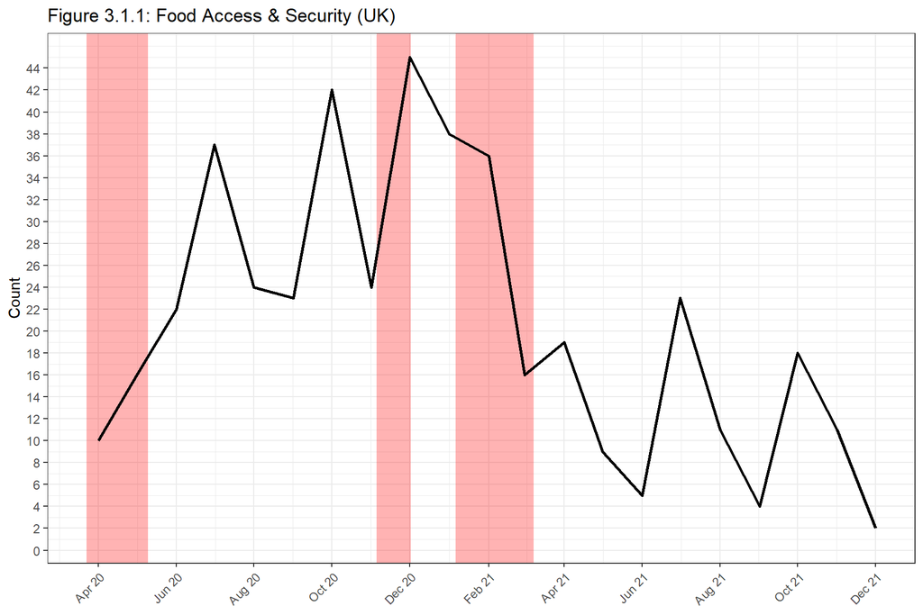

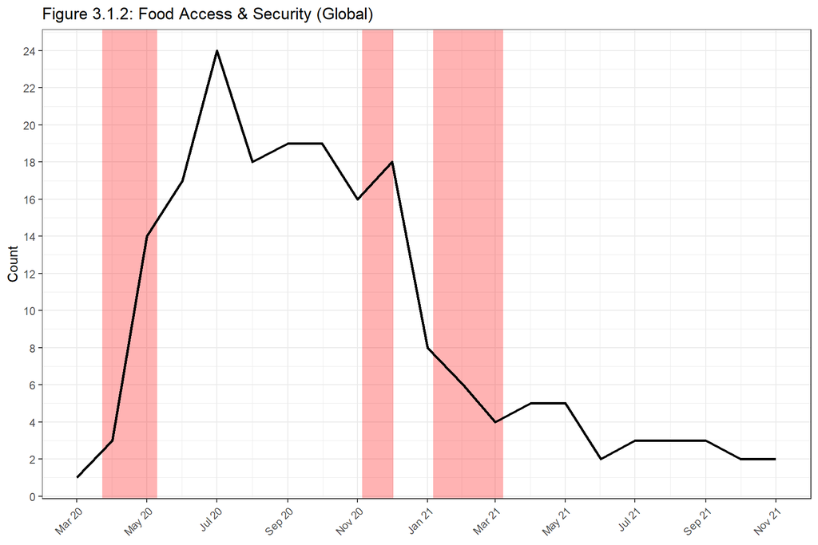

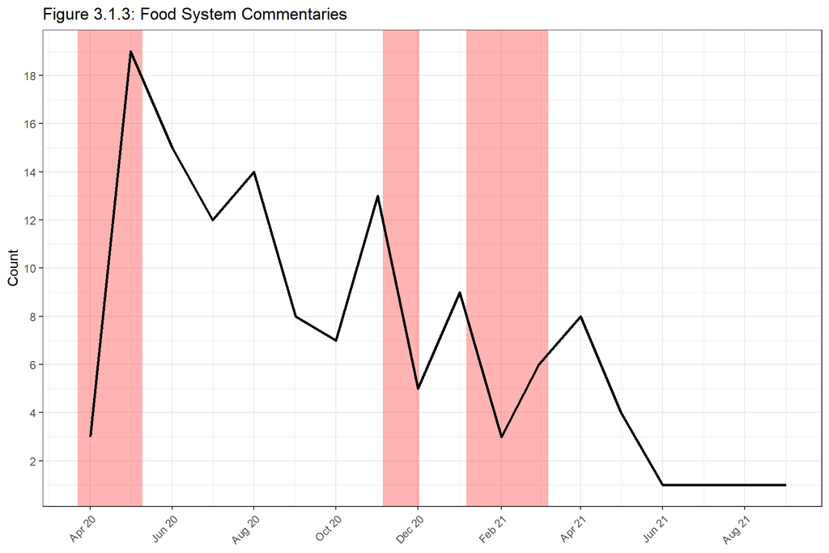

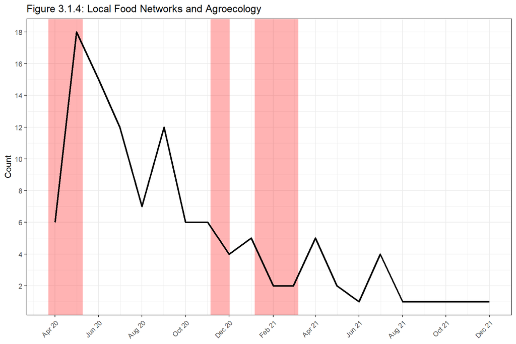

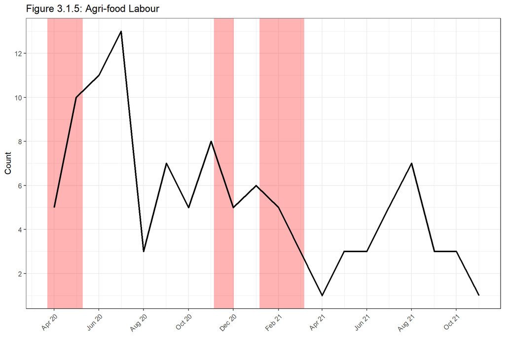

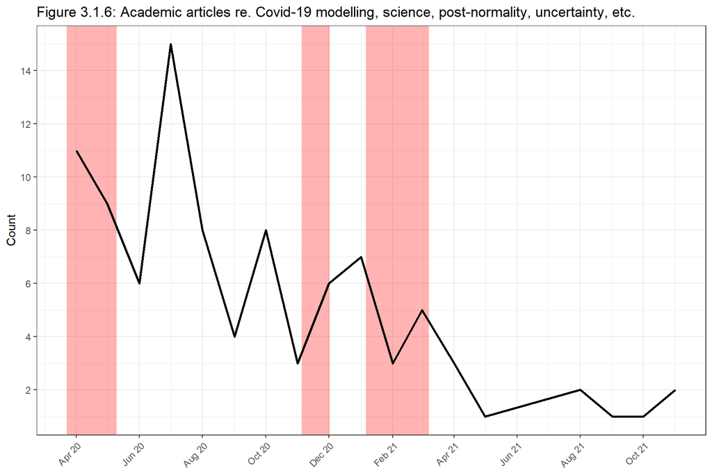

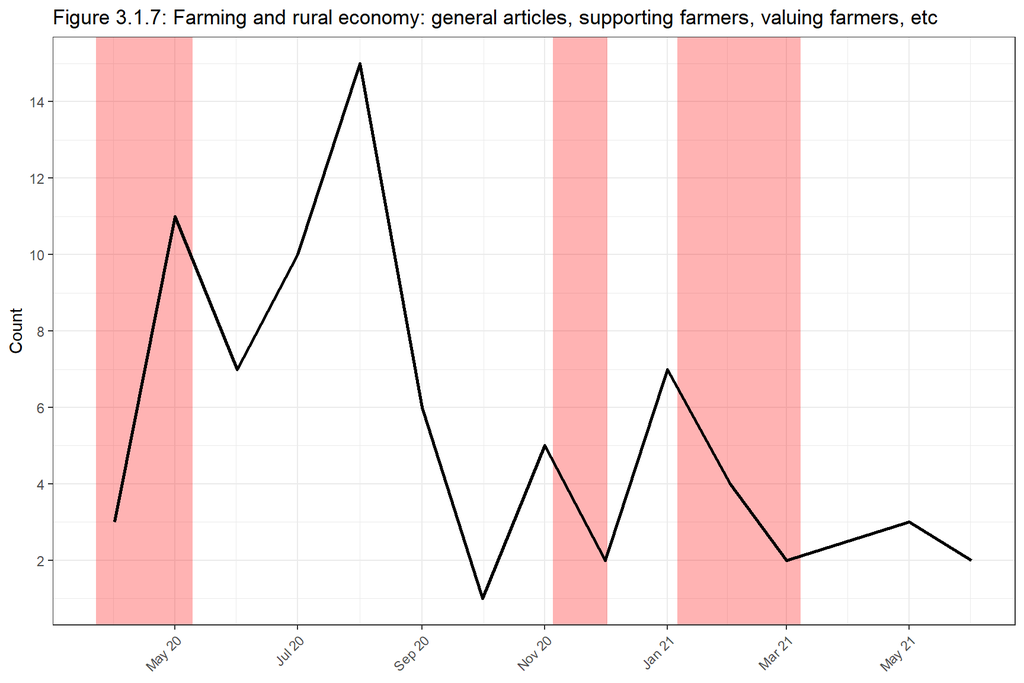

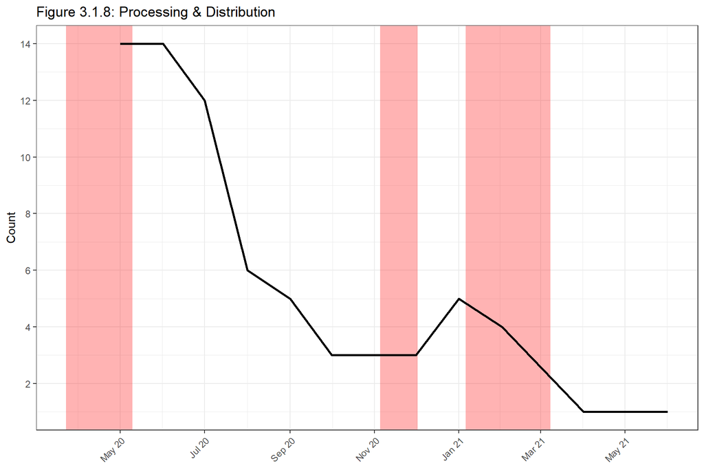

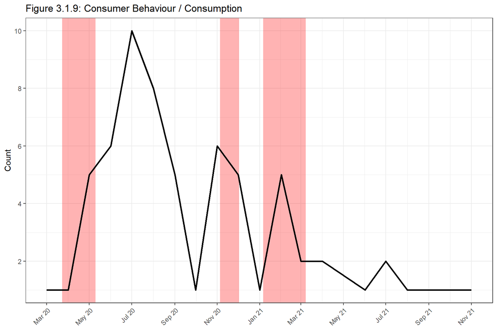

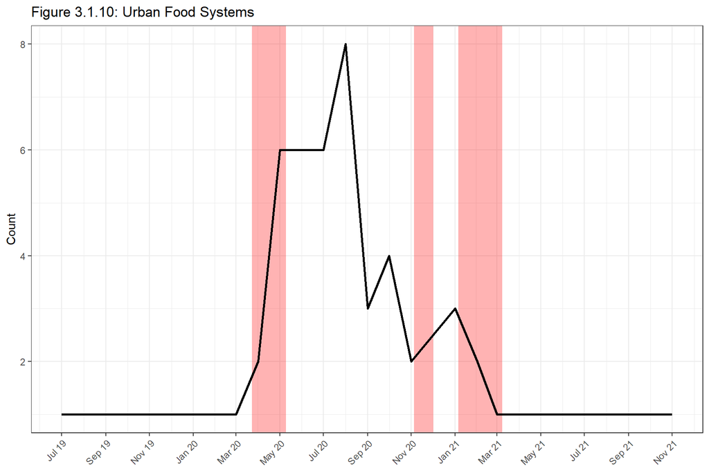

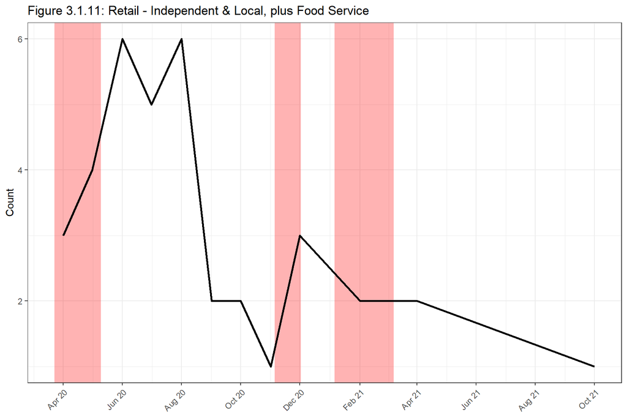

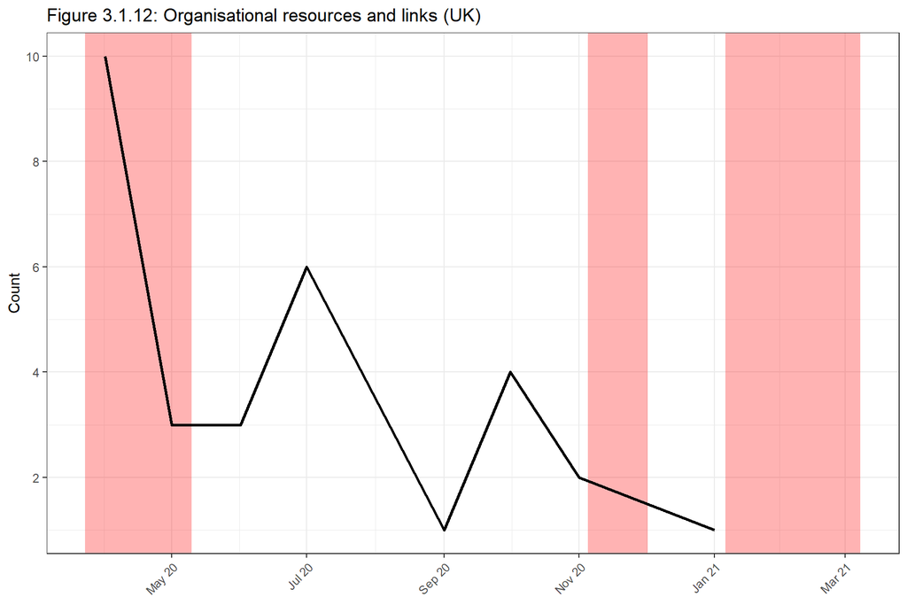

[7 more figures not shown]

## 4. Keywords: Count

Summary count of keywords in the database.

```
#> Split keyword string and create long format table - i.e. 1 keyword per row
```

```r
t4.1.kwords <- db |>
  mutate(Keyword = strsplit(as.character(KEYWORDS), ",")) |>
  unnest(Keyword)
```

```
#> Trim white space
```

```r
t4.1.kwords$Keyword <- trimws(t4.1.kwords$Keyword)
```

```
#> Remove duplicates and recount
```

```r
t4.1.kwords.count <- t4.1.kwords |>
  group_by(Keyword) |>
  summarise(Count = n()) |>
  arrange(desc(Count))
```

```
#> Render table on web page
```

```r
knitr::kable(t4.1.kwords.count, col.names = c("Keyword", "Count"), caption = "Table 4.1 Keyword count")
```

Table 4.1 Keyword count

| Keyword | Count |
| --- | --- |
| UK | 652 |
| food insecurity | 287 |
| food poverty | 226 |
| US | 211 |
| food systems | 181 |
| food security | 154 |
| global | 132 |
| food | 131 |
| local food | 125 |
| food banks | 122 |
| food access | 102 |
| resilience | 87 |
| agri-labour | 77 |
| consumption | 75 |
| health | 72 |
| free school meals | 70 |
| policy | 55 |
| Universal Credit | 53 |
| government | 52 |
| community | 51 |
| workers’ rights | 50 |
| aid | 49 |
| farming | 48 |
| hunger | 47 |
| food charities | 46 |
| meat processing | 44 |
| supply chains | 43 |
| consumer behaviour | 42 |
| supermarkets | 42 |
| trends | 41 |

[output cut: 456 more lines]

```
#> Export table as CSV file
```

```r
write_csv(t4.1.kwords.count, here("Out", "Descriptive_Stats", "4_Keywords_Count", "Tables", "Table4.1_Keywords_Count.csv"))
```

## 5. Keywords: Temporal analysis

Analysis of keyword frequency plotted over time, with periods of lockdown shown. The top 20 most frequently occurring keywords are shown (this can be easily extended to more or all keywords)

```
#> Get the 20 most frequently ocurring keywords
```

```r
t5.1.kwords.top20 <- t4.1.kwords.count |>
slice_max(Count, n = 20) |>
# drop unwanted Count column
select(Keyword)
```

```
#> Merge with main keywords table to extract top 20
```

```r
t5.1.kwords.plot <- merge(t4.1.kwords, t5.1.kwords.top20, by = "Keyword")
```

```
#> Get list of top 20 keywords for loop
```

```r
kwords <- as.list(t5.1.kwords.top20$Keyword)
```

```
#> Sequential integer counter for figure numbers
```

```r
i <-0
```

```
#> Initiate loop
```

```r
for(kword in kwords){
```

```
#> Loop counter (for table caption number)
```

```r
i <- i+1
```

```
#> Create data table (count of articles by sub-theme per main theme)
```

```r
t5.1_loop <- t4.1.kwords |>
 select(Keyword, DATE) |>
 filter(Keyword == kword) |>
 mutate(OBS = 1) |>
 mutate(Month = floor_date(DATE, unit = "month")) |>
 group_by(Month) |>
 summarise(Count = sum(OBS))
```

```
#> Get maximum value of Count for use in plotting
```

```r
max_val <- max(t5.1_loop$Count)
```

```
#> Plot
```

```r
p5.1 <- ggplot()+
  theme_bw() +
  ggtitle(paste0("Figure 5.", i , ": ", kword)) +
  geom_rect(data = Lockdowns, aes(xmin = date_start, xmax = date_end, ymin = -Inf, ymax = Inf),
            fill = "red", alpha= 0.3) +
  geom_line(data = t5.1_loop, aes(x=Month, y=Count), size = 1) +
  theme(axis.text.x = element_text(angle = 45, hjust = 1)) +
  scale_x_date(NULL, date_labels = "%b %y", date_breaks = "2 months") +
  scale_y_continuous(breaks = seq(0, max_val, by = 2)) +
  theme(axis.text.x = element_text(angle = 45, hjust = 1))
p5.1
```

```
#> Render on web page
```

```r
print(p5.1)
```

```
#> Export plots
```